# IE 423 Quality Engineering

# Project Part 1

# Necdet Sinan Parlar

We start by importing necessary libraries for our study. Pandas for manipulating data, matplotlib and seaborn for plotting, and statsmodels for modelling.

```python
import pandas as pd
import numpy as np
import statsmodels.api as sm
import matplotlib.pyplot as plt
import seaborn as sns
```

First thing to do is add the data to our workplace. Combining all csv files into a single dataframe.

```python
from zipfile import ZipFile

df = pd.concat(
    [pd.read_csv(ZipFile("project_part2_data.zip").open(i))
     for i in ZipFile("project_part2_data.zip").namelist()],
    ignore_index=True)
df.head()


df_train = df[(df['timestamp'] > '2022-01-01 09:00:00+03:00') & (df['timestamp'] < '2023-05-01 09:00:00+03:00')]
df_test = df[(df['timestamp'] > '2023-05-01 09:00:00+03:00')]
df_test.head()
```

|  | timestamp | price | short_name |
| --- | --- | --- | --- |
| 390376 | 2023-05-02 09:00:00+03:00 | 128.3 | THYAO |
| 390377 | 2023-05-02 10:00:00+03:00 | 128.3 | THYAO |
| 390378 | 2023-05-02 11:00:00+03:00 | 126.6 | THYAO |
| 390379 | 2023-05-02 12:00:00+03:00 | 127.6 | THYAO |
| 390380 | 2023-05-02 13:00:00+03:00 | 127.7 | THYAO |

# Task I

```python
In order to find which pairs of stock to work with we find the most correlated stocks.
```

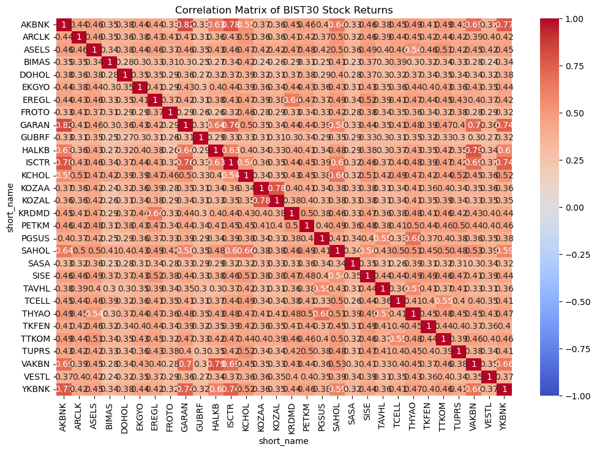

```
Highly correlated pairs:
('AKBNK', 'GARAN')
('AKBNK', 'ISCTR')
('AKBNK', 'YKBNK')
('GARAN', 'ISCTR')
('HALKB', 'VAKBN')
('KOZAA', 'KOZAL')
```

```python
# Pivot the DataFrame to have 'short_name' as columns and 'price' as values
pivot_df = df.pivot(index='timestamp', columns='short_name', values='price')
pivot_df.head()

# Calculate daily returns
returns = pivot_df.pct_change().dropna()
returns.tail()

# Calculate correlation matrix with pearson method (standard correlation coefficient)
correlation_matrix = returns.corr()
correlation_matrix.head()


# Plot a heatmap of the correlation matrix
plt.figure(figsize=(12, 8))
sns.heatmap(correlation_matrix, annot=True, cmap='coolwarm', vmin=-1, vmax=1)
plt.title('Correlation Matrix of BIST30 Stock Returns')
plt.show()

# Identify highly correlated pairs
threshold = 0.75  # Threshold can be adjusted based on preference
highly_correlated_pairs = []
for i in range(len(correlation_matrix.columns)):
    for j in range(i + 1, len(correlation_matrix.columns)):
        if abs(correlation_matrix.iloc[i, j]) > threshold:
            pair = (correlation_matrix.columns[i], correlation_matrix.columns[j])
            highly_correlated_pairs.append(pair)

print('Highly correlated pairs:')
for pair in highly_correlated_pairs:
    print(pair)
```

## 'AKBNK', 'GARAN'

```python
stockA, stockB = ('AKBNK', 'GARAN')


df_train_AK_GA = df_train[df_train['short_name'].isin([stockA, stockB])].pivot(index='timestamp', columns='short_name', values='price')
df_train_AK_GA.head()
```

| short_name timestamp | AKBNK | GARAN |
| --- | --- | --- |
| 2022-01-03 09:00:00+03:00 | 6.3248 | 10.2733 |
| 2022-01-03 10:00:00+03:00 | 6.3775 | 10.4098 |
| 2022-01-03 11:00:00+03:00 | 6.3950 | 10.4462 |
| 2022-01-03 12:00:00+03:00 | 6.4126 | 10.4371 |
| 2022-01-03 13:00:00+03:00 | 6.4038 | 10.4280 |

```
Linear Regression Results for AKBNK and GARAN:
                            OLS Regression Results
==============================================================================
Dep. Variable:                  GARAN   R-squared:                       0.946
Model:                            OLS   Adj. R-squared:                  0.946
Method:                 Least Squares   F-statistic:                 5.800e+04
Date:                Tue, 12 Dec 2023   Prob (F-statistic):               0.00
Time:                        18:15:40   Log-Likelihood:                -5775.0
No. Observations:                3290   AIC:                         1.155e+04
Df Residuals:                    3288   BIC:                         1.157e+04
Df Model:                           1
Covariance Type:            nonrobust
==============================================================================
                 coef    std err          t      P>|t|      [0.025      0.975]
------------------------------------------------------------------------------
const          2.3940      0.071     33.808      0.000       2.255       2.533
AKBNK          1.4120      0.006    240.832      0.000       1.401       1.424
==============================================================================
Omnibus:                      669.125   Durbin-Watson:                   0.009
Prob(Omnibus):                  0.000   Jarque-Bera (JB):             1774.939
Skew:                           1.086   Prob(JB):                         0.00
Kurtosis:                       5.869   Cond. No.                         35.2
==============================================================================

Notes:
[1] Standard Errors assume that the covariance matrix of the errors is correctly specified.
```

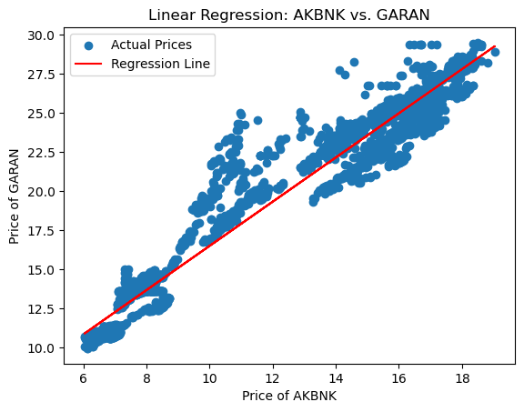

```python
# Perform linear regression using ordinary least squares
X = sm.add_constant(df_train_AK_GA[stockA])

model1 = sm.OLS(df_train_AK_GA[stockB], X).fit()

# Print regression summary
print(f"Linear Regression Results for {stockA} and {stockB}:")
print(model1.summary())

# Plot the regression line
plt.scatter(df_train_AK_GA[stockA], df_train_AK_GA[stockB], label='Actual Prices')
plt.plot(df_train_AK_GA[stockA], model1.predict(X), color='red', label='Regression Line')
plt.xlabel(f'Price of {stockA}')
plt.ylabel(f'Price of {stockB}')
plt.title(f'Linear Regression: {stockA} vs. {stockB}')
plt.legend()
plt.show()
```

We have trained our model with our training data. Now we test it.

```python
# Calculate residuals
residuals = model1.resid

# Calculate standard deviation of residuals
residual_std_dev = residuals.std()

# Establish control limits (e.g., 2 times the standard deviation)
control_limit = 2 * residual_std_dev

df_test_AK_GA = df_test[df_test['short_name'].isin([stockA, stockB])].pivot(index='timestamp', columns='short_name', values='price')
df_test_AK_GA['Predicted value of GARAN'] = 1.412*df_test_AK_GA['AKBNK'] + 2.394
df_test_AK_GA['Residual Value'] = df_test_AK_GA['Predicted value of GARAN'] - df_test_AK_GA['GARAN']

df_test_AK_GA['LCL'] = -control_limit
df_test_AK_GA['UCL'] = control_limit

# Generate trading signals based on control chart
df_test_AK_GA['Signal'] = 0  # 0 indicates no signal


df_test_AK_GA.loc[df_test_AK_GA['Residual Value'] > control_limit, 'Signal'] = -1  # -1 indicates short signal
df_test_AK_GA.loc[df_test_AK_GA['Residual Value'] < -control_limit, 'Signal'] = 1  # 1 indicates long signal

df_test_AK_GA.head()
```

| short_name timestamp | AKBNK | GARAN | Predicted value of GARAN | Residual Value | LCL | UCL | Signal |
| --- | --- | --- | --- | --- | --- | --- | --- |
| 2023-05-02 09:00:00+03:00 | 16.09 | 27.48 | 25.11308 | -2.36692 | -2.800168 | 2.800168 | 0 |
| 2023-05-02 10:00:00+03:00 | 16.21 | 27.86 | 25.28252 | -2.57748 | -2.800168 | 2.800168 | 0 |
| 2023-05-02 11:00:00+03:00 | 15.88 | 27.62 | 24.81656 | -2.80344 | -2.800168 | 2.800168 | 1 |
| 2023-05-02 12:00:00+03:00 | 15.99 | 27.72 | 24.97188 | -2.74812 | -2.800168 | 2.800168 | 0 |
| 2023-05-02 13:00:00+03:00 | 16.08 | 27.78 | 25.09896 | -2.68104 | -2.800168 | 2.800168 | 0 |

```python
# Simulate trading
initial_capital = 100000  # Set your initial trading capital
capital = initial_capital
position = 0  # 0 indicates no position

for i in range(1, len(df_test_AK_GA)):
    if df_test_AK_GA['Signal'].iloc[i] == 1 and position == 0:  # Long signal
        position = capital / df_test_AK_GA[stockA].iloc[i]  # Invest all capital in stockA
        capital = 0
    elif df_test_AK_GA['Signal'].iloc[i] == -1 and position > 0:  # Short signal and there is a long position
        capital = position * df_test_AK_GA[stockB].iloc[i]  # Sell stockB and convert to capital
        position = 0

# Calculate final capital
final_capital = capital + position * df_test_AK_GA[stockA].iloc[-1]

print(f"Trading simulation results for {stockA} and {stockB}:")
print(f"Initial Capital: {initial_capital}")
print(f"Final Capital: {final_capital}")
print(f"Total Return: {(final_capital - initial_capital) / initial_capital * 100:.2f}%")
print("------------")
```

```
Trading simulation results for AKBNK and GARAN:
Initial Capital: 100000
Final Capital: 191813.60201511334
Total Return: 91.81%
------------
```

## 'HALKB', 'VAKBN'

```
Linear Regression Results for HALKB and VAKBN:
                            OLS Regression Results
==============================================================================
Dep. Variable:                  VAKBN   R-squared:                       0.953
Model:                            OLS   Adj. R-squared:                  0.953
Method:                 Least Squares   F-statistic:                 6.644e+04
Date:                Tue, 12 Dec 2023   Prob (F-statistic):               0.00
Time:                        18:18:01   Log-Likelihood:                -3290.4
No. Observations:                3290   AIC:                             6585.
Df Residuals:                    3288   BIC:                             6597.
Df Model:                           1
Covariance Type:            nonrobust
==============================================================================
                 coef    std err          t      P>|t|      [0.025      0.975]
------------------------------------------------------------------------------
const         -0.8283      0.032    -25.995      0.000      -0.891      -0.766
HALKB          0.9690      0.004    257.763      0.000       0.962       0.976
==============================================================================
Omnibus:                      281.612   Durbin-Watson:                   0.010
Prob(Omnibus):                  0.000   Jarque-Bera (JB):              356.630
Skew:                           0.798   Prob(JB):                     3.62e-78
Kurtosis:                       3.228   Cond. No.                         23.8
==============================================================================

Notes:
[1] Standard Errors assume that the covariance matrix of the errors is correctly specified.
```

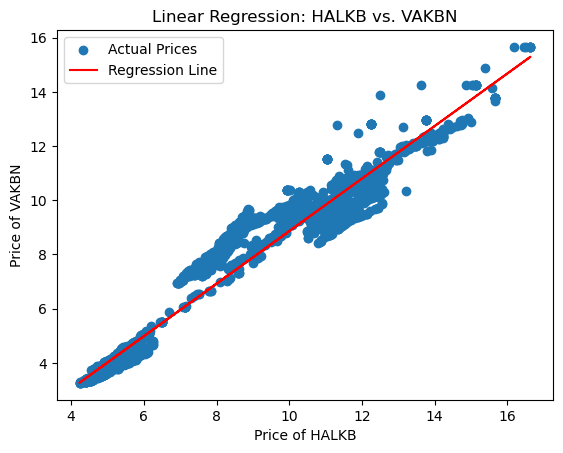

```python
stockC, stockD = ('HALKB', 'VAKBN')

df_train_HA_VA = df_train[df_train['short_name'].isin([stockC, stockD])].pivot(index='timestamp', columns='short_name', values='price')

# Perform linear regression using ordinary least squares
X = sm.add_constant(df_train_HA_VA[stockC])

model2 = sm.OLS(df_train_HA_VA[stockD], X).fit()

# Print regression summary
print(f"Linear Regression Results for {stockC} and {stockD}:")
print(model2.summary())

# Plot the regression line
plt.scatter(df_train_HA_VA[stockC], df_train_HA_VA[stockD], label='Actual Prices')
plt.plot(df_train_HA_VA[stockC], model2.predict(X), color='red', label='Regression Line')
plt.xlabel(f'Price of {stockC}')
plt.ylabel(f'Price of {stockD}')
plt.title(f'Linear Regression: {stockC} vs. {stockD}')
plt.legend()
plt.show()
```

We have trained our model with our training data. Now we test it.

```python
# Calculate residuals
residuals = model2.resid

# Calculate standard deviation of residuals
residual_std_dev = residuals.std()

# Establish control limits (e.g., 2 times the standard deviation)
control_limit = 2 * residual_std_dev

df_test_HA_VA = df_test[df_test['short_name'].isin([stockA, stockB])].pivot(index='timestamp', columns='short_name', values='price')
df_test_HA_VA['Predicted value of VAKBN'] = 0.9690*df_test_HA_VA['HALKB'] - 0.8283
df_test_HA_VA['Residual Value'] = df_test_HA_VA['Predicted value of VAKBN'] - df_test_HA_VA['VAKBN']

df_test_HA_VA['LCL'] = -control_limit
df_test_HA_VA['UCL'] = control_limit

# Generate trading signals based on control chart
df_test_HA_VA['Signal'] = 0  # 0 indicates no signal


df_test_HA_VA.loc[df_test_HA_VA['Residual Value'] > control_limit, 'Signal'] = 1  # -1 indicates short signal
df_test_HA_VA.loc[df_test_HA_VA['Residual Value'] < -control_limit, 'Signal'] = -1  # 1 indicates long signal

df_test_HA_VA.head()
```

[output not shown]

```python
# Simulate trading
initial_capital = 100000  # Set your initial trading capital
capital = initial_capital
position = 0  # 0 indicates no position

for i in range(1, len(df_test_HA_VA)):
    if df_test_HA_VA['Signal'].iloc[i] == 1 and position == 0:  # Long signal
        position = capital / df_test_HA_VA[stockA].iloc[i]  # Invest all capital in stockB
        capital = 0
    elif df_test_HA_VA['Signal'].iloc[i] == -1 and position > 0:  # Short signal and there is a long position
        capital = position * df_test_HA_VA[stockB].iloc[i]  # Sell stockA and convert to capital
        position = 0

# Calculate final capital
final_capital = capital + position * df_test_HA_VA[stockA].iloc[-1]

print(f"Trading simulation results for {stockA} and {stockB}:")
print(f"Initial Capital: {initial_capital}")
print(f"Final Capital: {final_capital}")
print(f"Total Return: {(final_capital - initial_capital) / initial_capital * 100:.2f}%")
print("------------")
```

[output not shown]

# TASK II

We model a Vector Autoregression model for this task. Start making our timeseries stationary.

## 'AKBNK', 'GARAN'

```python
from zipfile import ZipFile

df = pd.concat(
    [pd.read_csv(ZipFile("project_part2_data.zip").open(i))
     for i in ZipFile("project_part2_data.zip").namelist()],
    ignore_index=True)


df_train = df[(df['timestamp'] > '2022-01-01 09:00:00+03:00') & (df['timestamp'] < '2023-05-01 09:00:00+03:00')]
df_test = df[(df['timestamp'] > '2023-05-01 09:00:00+03:00')]
```

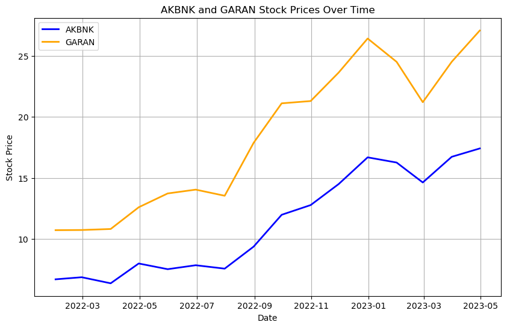

```python
stockA = 'GARAN'
stockB = 'AKBNK'
df_train_AK_GA = df_train[df_train['short_name'].isin([stockA, stockB])].pivot(index='timestamp', columns='short_name', values='price')
df_train_AK_GA.index = pd.to_datetime(df_train_AK_GA.index)

df_train_AK_GA_monthly = df_train_AK_GA.resample('M').mean()
df_train_AK_GA.head()
# Plotting
plt.figure(figsize=(10, 6))

# Plot AKBNK
plt.plot(df_train_AK_GA_monthly.index, df_train_AK_GA_monthly['AKBNK'], label='AKBNK', color='blue', linewidth=2)

# Plot GARAN
plt.plot(df_train_AK_GA_monthly.index, df_train_AK_GA_monthly['GARAN'], label='GARAN', color='orange', linewidth=2)

# Customize the plot
plt.title('AKBNK and GARAN Stock Prices Over Time')
plt.xlabel('Date')
plt.ylabel('Stock Price')
plt.legend()
plt.grid(True)

# Show the plot
plt.show()
```

Time series is not stationary. Normalizing.

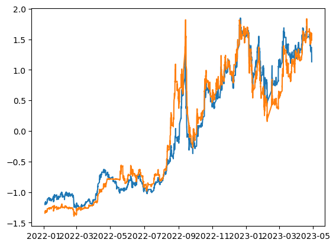

```python
AKBNK_series = df_train_AK_GA.AKBNK
GARAN_series = df_train_AK_GA.GARAN

def normalize(series):
    avg , dev = series.mean() , series.std()
    return (series-avg)/dev

AKBNK_series = normalize(AKBNK_series)
GARAN_series = normalize(GARAN_series)

plt.plot(AKBNK_series)
plt.plot(GARAN_series)
plt.show()
```

Take First Difference to remove stationary.

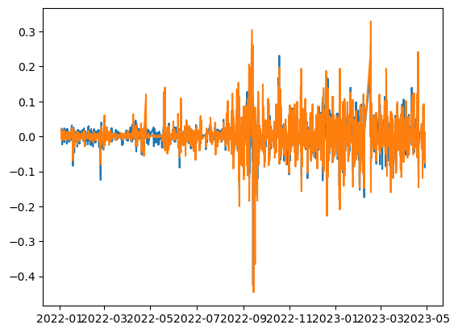

```python
AKBNK_series = AKBNK_series.diff().dropna()
GARAN_series = GARAN_series.diff().dropna()

plt.plot(AKBNK_series)
plt.plot(GARAN_series)
```

```python
from statsmodels.graphics.tsaplots import plot_acf, plot_pacf
from statsmodels.tsa.api import VAR

model3 = VAR(df_train_AK_GA)

model3_fit = model3.fit(maxlags=10)
model3_fit.summary()
```

```
  Summary of Regression Results
==================================
Model:                         VAR
Method:                        OLS
Date:           Tue, 12, Dec, 2023
Time:                     22:18:03
--------------------------------------------------------------------
No. of Equations:         2.00000    BIC:                   -8.12128
Nobs:                     3280.00    HQIC:                  -8.17138
Log likelihood:           4180.67    FPE:                0.000274837
AIC:                     -8.19933    Det(Omega_mle):     0.000271352
--------------------------------------------------------------------
Results for equation AKBNK
============================================================================
               coefficient       std. error           t-stat            prob
----------------------------------------------------------------------------
const             0.009829         0.007536            1.304           0.192
L1.AKBNK          1.077788         0.029924           36.017           0.000
L1.GARAN         -0.003006         0.017267           -0.174           0.862
L2.AKBNK         -0.045927         0.041823           -1.098           0.272
L2.GARAN         -0.029864         0.023588           -1.266           0.205
L3.AKBNK          0.068309         0.041837            1.633           0.103
L3.GARAN         -0.001041         0.023603           -0.044           0.965
L4.AKBNK         -0.059868         0.041922           -1.428           0.153
L4.GARAN          0.004733         0.023611            0.200           0.841
L5.AKBNK          0.019297         0.041852            0.461           0.645
L5.GARAN          0.004560         0.023563            0.194           0.847
L6.AKBNK         -0.097101         0.041820           -2.322           0.020
L6.GARAN          0.049997         0.023548            2.123           0.034
L7.AKBNK          0.020278         0.041891            0.484           0.628
L7.GARAN         -0.032947         0.023547           -1.399           0.162
L8.AKBNK          0.077139         0.041887            1.842           0.066
L8.GARAN         -0.023895         0.023506           -1.017           0.309
L9.AKBNK         -0.067456         0.041898           -1.610           0.107
L9.GARAN          0.066498         0.023504            2.829           0.005
L10.AKBNK         0.007504         0.030100            0.249           0.803
L10.GARAN        -0.035410         0.017254           -2.052           0.040
============================================================================

Results for equation GARAN
```

[output cut: 15 more lines]

```
L6.GARAN          0.061617         0.040774            1.511           0.131
L7.AKBNK         -0.021559         0.072537           -0.297           0.766
L7.GARAN         -0.029408         0.040774           -0.721           0.471
L8.AKBNK         -0.016314         0.072530           -0.225           0.822
L8.GARAN          0.045520         0.040702            1.118           0.263
L9.AKBNK         -0.058952         0.072548           -0.813           0.416
L9.GARAN          0.072112         0.040698            1.772           0.076
L10.AKBNK         0.045432         0.052120            0.872           0.383
L10.GARAN        -0.088716         0.029877           -2.969           0.003
============================================================================

Correlation matrix of residuals
            AKBNK     GARAN
AKBNK    1.000000  0.810801
GARAN    0.810801  1.000000
```

By interpreting the above summary we find that our model for predicting 'GARAN' is: Predict_GARAN = L1.AKBNK*0.220087 + L1.GARAN* 0.925838 - L2.AKBNK*(-0.223585) + L3.AKBNK* 0.241785 - L10.GARAN * -0.088716

```python
df_test_AK_GA = df_test[df_test['short_name'].isin([stockA, stockB])].pivot(index='timestamp', columns='short_name', values='price')
df_test_AK_GA.index = pd.to_datetime(df_test_AK_GA.index)
df_test_AK_GA.head()
```

| short_name timestamp | AKBNK | GARAN |
| --- | --- | --- |
| 2023-05-02 09:00:00+03:00 | 16.09 | 27.48 |
| 2023-05-02 10:00:00+03:00 | 16.21 | 27.86 |
| 2023-05-02 11:00:00+03:00 | 15.88 | 27.62 |
| 2023-05-02 12:00:00+03:00 | 15.99 | 27.72 |
| 2023-05-02 13:00:00+03:00 | 16.08 | 27.78 |

```python
# Ensure data types are numeric
df_train_AK_GA['AKBNK'] = pd.to_numeric(df_train_AK_GA['AKBNK'], errors='coerce')
df_train_AK_GA['GARAN'] = pd.to_numeric(df_train_AK_GA['GARAN'], errors='coerce')

# Calculate the 'Predicted value of GARAN' column
df_train_AK_GA['Predicted value of GARAN'] = (
    0.220087 * df_train_AK_GA['AKBNK'].shift(1)+
     0.925838 * df_train_AK_GA['GARAN'].shift(1) +
     (-0.223585) * df_train_AK_GA['AKBNK'].shift(2)+
     0.241785 * df_train_AK_GA['AKBNK'].shift(3) + (-0.088716) * df_train_AK_GA['GARAN'].shift(10))


df_train_AK_GA['Residual_Value'] = df_train_AK_GA['Predicted value of GARAN'] - df_train_AK_GA['GARAN']

df_train_AK_GA.dropna().head()
```

[output not shown]

```python
# Calculate residuals
residuals = df_train_AK_GA.Residual_Value

# Calculate standard deviation of residuals
residual_std_dev = residuals.std()

# Establish control limits (e.g., 2 times the standard deviation)
control_limit = 2 * residual_std_dev

stockA = 'AKBNK'
stockB = 'GARAN'

# Now testing on our testing data
df_test_AK_GA = df_test[df_test['short_name'].isin([stockA, stockB])].pivot(index='timestamp', columns='short_name', values='price')
df_test_AK_GA['Predicted value of GARAN'] = (
    0.220087 * df_test_AK_GA['AKBNK'].shift(1)+
     0.925838 * df_test_AK_GA['GARAN'].shift(1) +
     (-0.223585) * df_test_AK_GA['AKBNK'].shift(2)+
     0.241785 * df_test_AK_GA['AKBNK'].shift(3) + (-0.088716) * df_test_AK_GA['GARAN'].shift(10))

df_test_AK_GA['Residual Value'] = df_test_AK_GA['Predicted value of GARAN'] - df_test_AK_GA['GARAN']

df_test_AK_GA['LCL'] = -control_limit
df_test_AK_GA['UCL'] = control_limit

# Generate trading signals based on control chart
df_test_AK_GA['Signal'] = 0  # 0 indicates no signal


df_test_AK_GA.loc[df_test_AK_GA['Residual Value'] > control_limit, 'Signal'] = 1  # -1 indicates short signal
df_test_AK_GA.loc[df_test_AK_GA['Residual Value'] < -control_limit, 'Signal'] = -1  # 1 indicates long signal

df_test_AK_GA.dropna().head()
```

| short_name timestamp | AKBNK | GARAN | Predicted value of GARAN | Residual Value | LCL | UCL | Signal |
| --- | --- | --- | --- | --- | --- | --- | --- |
| 2023-05-03 09:00:00+03:00 | 15.72 | 27.72 | 26.931377 | -0.788623 | -0.633129 | 0.633129 | -1 |
| 2023-05-03 10:00:00+03:00 | 15.66 | 27.56 | 26.937563 | -0.622437 | -0.633129 | 0.633129 | 0 |
| 2023-05-03 11:00:00+03:00 | 15.31 | 27.30 | 26.786337 | -0.513663 | -0.633129 | 0.633129 | 0 |
| 2023-05-03 12:00:00+03:00 | 15.40 | 27.36 | 26.485221 | -0.874779 | -0.633129 | 0.633129 | -1 |
| 2023-05-03 13:00:00+03:00 | 15.40 | 27.28 | 26.619004 | -0.660996 | -0.633129 | 0.633129 | -1 |

```python
# Simulate trading
initial_capital = 100000  # Set your initial trading capital
capital = initial_capital
position = 0  # 0 indicates no position

for i in range(1, len(df_test_AK_GA)):
    if df_test_AK_GA['Signal'].iloc[i] == 1 and position == 0:  # Long signal
        position = capital / df_test_AK_GA[stockA].iloc[i]  # Invest all capital in stockA
        capital = 0
    elif df_test_AK_GA['Signal'].iloc[i] == -1 and position > 0:  # Short signal and there is a long position
        capital = position * df_test_AK_GA[stockB].iloc[i]  # Sell stockB and convert to capital
        position = 0

# Calculate final capital
final_capital = capital + position * df_test_AK_GA[stockA].iloc[-1]

print(f"Trading simulation results for {stockA} and {stockB}:")
print(f"Initial Capital: {initial_capital}")
print(f"Final Capital: {final_capital}")
print(f"Total Return: {(final_capital - initial_capital) / initial_capital * 100:.2f}%")
print("------------")
```

```
Trading simulation results for AKBNK and GARAN:
Initial Capital: 100000
Final Capital: 21814721.603460204
Total Return: 21714.72%
------------
```

## 'HALKB', 'VAKBN'

```python
from zipfile import ZipFile

df = pd.concat(
    [pd.read_csv(ZipFile("project_part2_data.zip").open(i))
     for i in ZipFile("project_part2_data.zip").namelist()],
    ignore_index=True)


df_train = df[(df['timestamp'] > '2022-01-01 09:00:00+03:00') & (df['timestamp'] < '2023-05-01 09:00:00+03:00')]
df_test = df[(df['timestamp'] > '2023-05-01 09:00:00+03:00')]
```

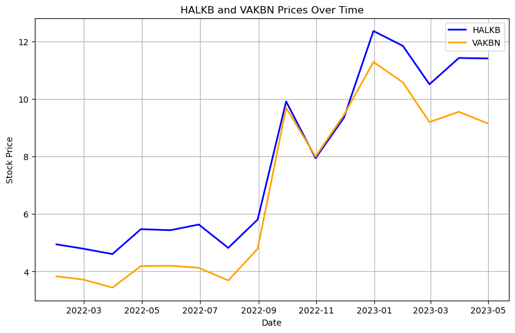

```python
stockA = 'HALKB'
stockB = 'VAKBN'
df_train_HA_VA = df_train[df_train['short_name'].isin([stockA, stockB])].pivot(index='timestamp', columns='short_name', values='price')
df_train_HA_VA.index = pd.to_datetime(df_train_AK_GA.index)

df_train_HA_VA_monthly = df_train_HA_VA.resample('M').mean()
df_train_HA_VA.head()
# Plotting
plt.figure(figsize=(10, 6))

# Plot HALKB
plt.plot(df_train_HA_VA_monthly.index, df_train_HA_VA_monthly['HALKB'], label='HALKB', color='blue', linewidth=2)

# Plot VAKBN
plt.plot(df_train_HA_VA_monthly.index, df_train_HA_VA_monthly['VAKBN'], label='VAKBN', color='orange', linewidth=2)

# Customize the plot
plt.title('HALKB and VAKBN Prices Over Time')
plt.xlabel('Date')
plt.ylabel('Stock Price')
plt.legend()
plt.grid(True)

# Show the plot
plt.show()
```

Time series is not stationary. Normalizing.

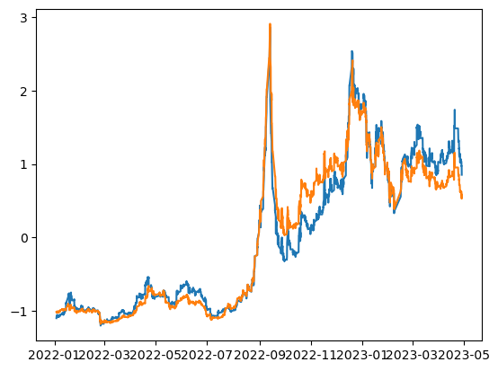

```python
HALKB_series = df_train_HA_VA.HALKB
VAKBN_series = df_train_HA_VA.VAKBN

def normalize(series):
    avg , dev = series.mean() , series.std()
    return (series-avg)/dev

HALKB_series = normalize(HALKB_series)
VAKBN_series = normalize(VAKBN_series)

plt.plot(HALKB_series)
plt.plot(VAKBN_series)
plt.show()
```

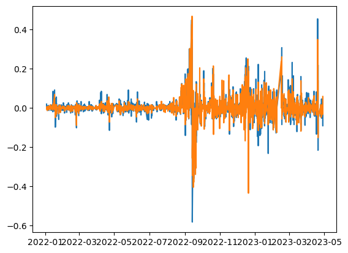

```python
HALKB_series = HALKB_series.diff().dropna()
VAKBN_series = VAKBN_series.diff().dropna()

plt.plot(HALKB_series)
plt.plot(VAKBN_series)
```

```python
from statsmodels.graphics.tsaplots import plot_acf, plot_pacf
from statsmodels.tsa.api import VAR

model4 = VAR(df_train_HA_VA)

model4_fit = model4.fit(maxlags=10)
model4_fit.summary()
```

```
  Summary of Regression Results
==================================
Model:                         VAR
Method:                        OLS
Date:           Tue, 12, Dec, 2023
Time:                     23:07:56
--------------------------------------------------------------------
No. of Equations:         2.00000    BIC:                   -9.79154
Nobs:                     3280.00    HQIC:                  -9.84164
Log likelihood:           6919.90    FPE:                5.17238e-05
AIC:                     -9.86959    Det(Omega_mle):     5.10678e-05
--------------------------------------------------------------------
Results for equation HALKB
============================================================================
               coefficient       std. error           t-stat            prob
----------------------------------------------------------------------------
const             0.010677         0.006599            1.618           0.106
L1.HALKB          1.112658         0.032425           34.314           0.000
L1.VAKBN         -0.000404         0.037128           -0.011           0.991
L2.HALKB         -0.144640         0.043048           -3.360           0.001
L2.VAKBN          0.052450         0.046759            1.122           0.262
L3.HALKB          0.006198         0.043269            0.143           0.886
L3.VAKBN          0.028340         0.046921            0.604           0.546
L4.HALKB          0.048769         0.043277            1.127           0.260
L4.VAKBN         -0.121677         0.047026           -2.587           0.010
L5.HALKB         -0.022905         0.043329           -0.529           0.597
L5.VAKBN          0.029949         0.047092            0.636           0.525
L6.HALKB         -0.008874         0.043334           -0.205           0.838
L6.VAKBN          0.048012         0.047098            1.019           0.308
L7.HALKB         -0.002756         0.043274           -0.064           0.949
L7.VAKBN         -0.030198         0.047038           -0.642           0.521
L8.HALKB         -0.027229         0.043238           -0.630           0.529
L8.VAKBN          0.039796         0.046916            0.848           0.396
L9.HALKB          0.183239         0.043190            4.243           0.000
L9.VAKBN         -0.207782         0.046881           -4.432           0.000
L10.HALKB        -0.146635         0.032881           -4.460           0.000
L10.VAKBN         0.162681         0.037292            4.362           0.000
============================================================================

Results for equation VAKBN
```

[output cut: 15 more lines]

```
L6.VAKBN          0.050039         0.041168            1.215           0.224
L7.HALKB          0.014792         0.037826            0.391           0.696
L7.VAKBN         -0.024720         0.041116           -0.601           0.548
L8.HALKB         -0.056296         0.037795           -1.490           0.136
L8.VAKBN          0.080889         0.041009            1.972           0.049
L9.HALKB          0.149792         0.037752            3.968           0.000
L9.VAKBN         -0.146071         0.040979           -3.565           0.000
L10.HALKB        -0.109537         0.028741           -3.811           0.000
L10.VAKBN         0.080893         0.032597            2.482           0.013
============================================================================

Correlation matrix of residuals
            HALKB     VAKBN
HALKB    1.000000  0.842691
VAKBN    0.842691  1.000000
```

By interpreting the above summary we find that our model for predicting 'VAKBN' is: Predict_VAKBN = L1.HALKB.0.272000 + L1.VAKBN *0.757602 + L2.HALKB(-0.160481) + L9.HALKB* 0.149792 + L9.VAKBN *(-0.146071) + L10.HALKB*(-0.109537)

```python
# Ensure data types are numeric
df_train_HA_VA['HALKB'] = pd.to_numeric(df_train_HA_VA['HALKB'], errors='coerce')
df_train_HA_VA['VAKBN'] = pd.to_numeric(df_train_HA_VA['VAKBN'], errors='coerce')

# Calculate the 'Predicted value of VAKBN' column
df_train_HA_VA['Predicted value of VAKBN'] = (
    0.272 * df_train_HA_VA['HALKB'].shift(1)+
     0.757602 * df_train_HA_VA['VAKBN'].shift(1) +
     (-0.160481) * df_train_HA_VA['HALKB'].shift(2)+
     0.149792 * df_train_HA_VA['HALKB'].shift(9) + (-0.146071) * df_train_HA_VA['VAKBN'].shift(9) +
    (-0.109537) * df_train_HA_VA['HALKB'].shift(10))


df_train_HA_VA['Residual_Value'] = df_train_HA_VA['Predicted value of VAKBN'] - df_train_HA_VA['VAKBN']

df_train_AK_GA.dropna().head()
```

| short_name timestamp | AKBNK | GARAN | Predicted value of GARAN | Residual Value | Residual_Value |
| --- | --- | --- | --- | --- | --- |
| 2022-01-04 09:00:00+03:00 | 6.4389 | 10.4553 | 10.270997 | -0.184303 | -0.184303 |
| 2022-01-04 10:00:00+03:00 | 6.5269 | 10.5371 | 10.288601 | -0.248499 | -0.248499 |
| 2022-01-04 11:00:00+03:00 | 6.5005 | 10.5007 | 10.382576 | -0.118124 | -0.118124 |
| 2022-01-04 12:00:00+03:00 | 6.4653 | 10.4643 | 10.324197 | -0.140103 | -0.140103 |
| 2022-01-04 13:00:00+03:00 | 6.4741 | 10.4371 | 10.310737 | -0.126363 | -0.126363 |

```python
# Calculate residuals
residuals = df_train_HA_VA.Residual_Value

# Calculate standard deviation of residuals
residual_std_dev = residuals.std()

# Establish control limits (e.g., 2 times the standard deviation)
control_limit = 2 * residual_std_dev

stockA = 'HALKB'
stockB = 'VAKBN'

# Now testing on our testing data
df_test_HA_VA = df_test[df_test['short_name'].isin([stockA, stockB])].pivot(index='timestamp', columns='short_name', values='price')
df_test_HA_VA['Predicted value of VAKBN'] = (
    0.272 * df_test_HA_VA['HALKB'].shift(1)+
     0.757602 * df_test_HA_VA['VAKBN'].shift(1) +
     (-0.160481) * df_test_HA_VA['HALKB'].shift(2)+
     0.149792 * df_test_HA_VA['HALKB'].shift(9) + (-0.146071) * df_test_HA_VA['VAKBN'].shift(9) +
    (-0.109537) * df_test_HA_VA['HALKB'].shift(10))


df_test_HA_VA['Residual Value'] = df_test_HA_VA['Predicted value of VAKBN'] - df_test_HA_VA['VAKBN']

df_test_HA_VA['LCL'] = -control_limit
df_test_HA_VA['UCL'] = control_limit

# Generate trading signals based on control chart
df_test_HA_VA['Signal'] = 0  # 0 indicates no signal


df_test_HA_VA.loc[df_test_HA_VA['Residual Value'] > control_limit, 'Signal'] = 1  # -1 indicates short signal
df_test_HA_VA.loc[df_test_HA_VA['Residual Value'] < -control_limit, 'Signal'] = -1  # 1 indicates long signal

df_test_HA_VA.dropna().tail()
```

| short_name timestamp | HALKB | VAKBN | Predicted value of VAKBN | Residual Value | LCL | UCL | Signal |
| --- | --- | --- | --- | --- | --- | --- | --- |
| 2023-11-21 09:00:00+03:00 | 13.25 | 15.20 | 11.247739 | -3.952261 | -1.473752 | 1.473752 | -1 |
| 2023-11-21 10:00:00+03:00 | 13.21 | 15.19 | 11.281035 | -3.908965 | -1.473752 | 1.473752 | -1 |
| 2023-11-21 11:00:00+03:00 | 13.16 | 15.16 | 11.266163 | -3.893837 | -1.473752 | 1.473752 | -1 |
| 2023-11-21 12:00:00+03:00 | 13.15 | 15.14 | 11.233072 | -3.906928 | -1.473752 | 1.473752 | -1 |
| 2023-11-21 13:00:00+03:00 | 13.07 | 15.08 | 11.223737 | -3.856263 | -1.473752 | 1.473752 | -1 |

```python
# Simulate trading
initial_capital = 100000  # Set your initial trading capital
capital = initial_capital
position = 0  # 0 indicates no position

for i in range(1, len(df_test_HA_VA)):
    if df_test_HA_VA['Signal'].iloc[i] == 1 and position == 0:  # Long signal
        position = capital / df_test_HA_VA[stockA].iloc[i]  # Invest all capital in stockA
        capital = 0
    elif df_test_HA_VA['Signal'].iloc[i] == -1 and position > 0:  # Short signal and there is a long position
        capital = position * df_test_HA_VA[stockB].iloc[i]  # Sell stockB and convert to capital
        position = 0

# Calculate final capital
final_capital = capital + position * df_test_HA_VA[stockA].iloc[-1]

print(f"Trading simulation results for {stockA} and {stockB}:")
print(f"Initial Capital: {initial_capital}")
print(f"Final Capital: {final_capital}")
print(f"Total Return: {(final_capital - initial_capital) / initial_capital * 100:.2f}%")
print("------------")
```

```
Trading simulation results for HALKB and VAKBN:
Initial Capital: 100000
Final Capital: 100000.0
Total Return: 0.00%
------------
```